# Quantium Data Analytics Virtual Internship

# Assignment 2: Experimentation and uplifting test

This project picks up where we ended in the last project, in our previous analysis we recommended that products should be positioned in a specific manner to attract more customers, the client used the insights gained in the customer purchasing behaviours to place the chips in a specific manner.

These layouts were trailed in 3 stores, stores 77, 86 and 88. In this task we must evaluate the performance of a store trial.

We will create a measure to compare different control stores to each of the trial stores to do this we will create a function to reduce having to re-do the analysis for each trial store.

Once we have selected our control stores, we will compare each trial and control pair during the trial period. We want to test if total sales are significantly different in the trial period and if so, we check if the driver of change is more purchasing customers or more purchases per customers etc.

```python
# Import Libraries
import pandas as pd
import numpy as np
import matplotlib.pyplot as plt
import seaborn as sns
from scipy.stats import t
from scipy.stats import ttest_ind
import matplotlib.dates as mdates
import warnings
warnings.filterwarnings('ignore')
```

```python
# Connect to dataset
data_full = pd.read_csv('data_final.csv')
```

### Preparing the datasets

```python
# Selecting data from the transactions data that we will use to create metrics to select control stores.
data = data_full[['date', 'store_nbr', 'lylty_card_nbr',
                  'txn_id', 'prod_qty', 'tot_sales']]

# Take a look at the new dataframe
data.head()
```

|  | date | store_nbr | lylty_card_nbr | txn_id | prod_qty | tot_sales |
| --- | --- | --- | --- | --- | --- | --- |
| 0 | 2018-10-17 | 1 | 1000 | 1 | 2 | 6.0 |
| 1 | 2019-05-14 | 1 | 1307 | 348 | 3 | 6.3 |
| 2 | 2018-11-10 | 1 | 1307 | 346 | 2 | 3.8 |
| 3 | 2019-03-09 | 1 | 1307 | 347 | 1 | 2.1 |
| 4 | 2019-05-20 | 1 | 1343 | 383 | 2 | 2.9 |

```python
# Set date column to date format
data['date'] = pd.to_datetime(data.date)
# Create a YearMonth columns
data.insert(1, 'year_month', data['date'].dt.to_period('M'))
data.head()
```

|  | date | year_month | store_nbr | lylty_card_nbr | txn_id | prod_qty | tot_sales |
| --- | --- | --- | --- | --- | --- | --- | --- |
| 0 | 2018-10-17 | 2018-10 | 1 | 1000 | 1 | 2 | 6.0 |
| 1 | 2019-05-14 | 2019-05 | 1 | 1307 | 348 | 3 | 6.3 |
| 2 | 2018-11-10 | 2018-11 | 1 | 1307 | 346 | 2 | 3.8 |
| 3 | 2019-03-09 | 2019-03 | 1 | 1307 | 347 | 1 | 2.1 |
| 4 | 2019-05-20 | 2019-05 | 1 | 1343 | 383 | 2 | 2.9 |

```python
# Which stores have less than 12 months of operation ?
check = data.groupby('store_nbr')['year_month'].nunique()
check = check[check < 12]
check = list(check.index)
print('These are the stores that have less than 12 months of opperation:\n', check)
```

```
These are the stores that have less than 12 months of opperation:
 [11, 31, 44, 76, 85, 92, 117, 177, 193, 206, 218, 252]
```

```python
# Remove the stores with less than 12 months of operation from the dataset
print('Before removing any stores we had a total of {} stores.\n'.format(
    data.store_nbr.nunique()))
print('We will remove {} stores that have incomplete records.\n'.format(len(check)))
indices_to_drop = data[data['store_nbr'].isin(check)].index
data = data.drop(indices_to_drop)
print('We now have the records of {} stores'.format(data.store_nbr.nunique()))
```

```
Before removing any stores we had a total of 271 stores.

We will remove 12 stores that have incomplete records.

We now have the records of 259 stores
```

We will select our control stores based on how close their monthly performance is to the trail stores. We will use total revenue and total number of customers who visited the store as metrics to decide which store is best suited as a control store.

For later analysis we shall create extra metrics on a monthly scale that will help analyse the impact of the trail.

```python
# Change year_month datatype to aid ploting
data['year_month'] = data.year_month.astype('str')
```

```python
data[:2]
```

|  | date | year_month | store_nbr | lylty_card_nbr | txn_id | prod_qty | tot_sales |
| --- | --- | --- | --- | --- | --- | --- | --- |
| 0 | 2018-10-17 | 2018-10 | 1 | 1000 | 1 | 2 | 6.0 |
| 1 | 2019-05-14 | 2019-05 | 1 | 1307 | 348 | 3 | 6.3 |

Metrics we need to use for store comparison and performance analysis:

- Total Sales - Revenue
- Number of customers - Count on Customers
- Number of chips per customer - Total products sold / Total Customers
- Avg Price per unit - Total sales / Total products

```python
# Create metrics dataframe
monthly_metrics = data.groupby(['store_nbr', 'year_month'], as_index=False).agg({
    'tot_sales': 'sum',
    'lylty_card_nbr': [lambda x: x.nunique()],
    'prod_qty': 'sum',

})
monthly_metrics.columns = ['Store', 'Period',
                           'Revenue', 'NCustomers', 'TotalUnits']
monthly_metrics['ChipsPerCust'] = monthly_metrics['TotalUnits'] / \
    monthly_metrics['NCustomers']
monthly_metrics['AvgPriceUnit'] = monthly_metrics['Revenue'] / \
    monthly_metrics['TotalUnits']
monthly_metrics.drop(columns='TotalUnits', inplace=True)
monthly_metrics
```

|  | Store | Period | Revenue | NCustomers | ChipsPerCust | AvgPriceUnit |
| --- | --- | --- | --- | --- | --- | --- |
| 0 | 1 | 2018-07 | 188.9 | 47 | 1.234043 | 3.256897 |
| 1 | 1 | 2018-08 | 168.4 | 41 | 1.268293 | 3.238462 |
| 2 | 1 | 2018-09 | 268.1 | 57 | 1.245614 | 3.776056 |
| 3 | 1 | 2018-10 | 175.4 | 39 | 1.307692 | 3.439216 |
| 4 | 1 | 2018-11 | 184.8 | 44 | 1.250000 | 3.360000 |
| ... | ... | ... | ... | ... | ... | ... |
| 3103 | 272 | 2019-02 | 385.3 | 44 | 2.022727 | 4.329213 |
| 3104 | 272 | 2019-03 | 421.9 | 48 | 2.020833 | 4.349485 |
| 3105 | 272 | 2019-04 | 445.1 | 54 | 1.944444 | 4.239048 |
| 3106 | 272 | 2019-05 | 314.6 | 34 | 2.088235 | 4.430986 |
| 3107 | 272 | 2019-06 | 301.9 | 33 | 2.060606 | 4.439706 |

3108 rows × 6 columns

```python
# Create datasets for pre trial and trail periods
pre_df = monthly_metrics[monthly_metrics['Period'] < "2019-02"]
trial_df = monthly_metrics[(monthly_metrics['Period'] >=
                            "2019-02") & (monthly_metrics['Period'] <= "2019-04")]
```

## Selecting the control stores

### Create the functions to select control store

Now we have metrics we can use to compare store performance and analyse impact of the trial. Revenue & Total visits will give use a way of figuring out which stores are most alike.

Units Per Customer and Average price per unit are drivers of sales that will come in handy in explaining how the trail has affected sales if any affect is noted.

Now let’s create a function that compares all potential control stores to the trail store in question and returns the best match. We will use persons correlation as a measure to select the control store and combine the correlation with a magnitude difference between sales and number of customers, this way we ensure we find control stores that have the same trend and scale of performance.

```python
# Create a function which calculates the correlation between trial store and other stores based on a single metric

def calculateCorrelation(inputTable, metric, trial_store):
    output = pd.DataFrame({'Trail': [], 'Control': [], 'Correlation': []})
    a = inputTable.loc[inputTable['Store'] == trial_store, metric]
    a.reset_index(drop=True, inplace=True)
    storeNumbers = inputTable['Store'].unique()
    for i in storeNumbers:
        b = inputTable.loc[inputTable['Store'] == i, metric]
        b.reset_index(drop=True, inplace=True)
        output = output.append(
            {'Trail': trial_store, 'Control': i, 'Correlation': b.corr(a)}, ignore_index=True)
    return output
```

```python
# Create another function which calculates a standardised magnitude difference

def calculateMagnitudeDistance(inputTable, metric, trial_store):
    output = pd.DataFrame({'Trail': [], 'Control': [], 'Magnitude': []})
    a = inputTable.loc[inputTable['Store'] == trial_store, metric]
    a.reset_index(drop=True, inplace=True)
    storeNumbers = inputTable['Store'].unique()
    for i in storeNumbers:
        b = inputTable.loc[inputTable['Store'] == i, metric]
        b.reset_index(drop=True, inplace=True)
        c = abs(a-b)
        d = np.mean(1-(c-min(c))/(max(c)-min(c)))
        output = output.append(
            {'Trail': trial_store, 'Control': i, 'Magnitude': d}, ignore_index=True)
    return output
```

```python
# Create a function to select control store using correlation and magnitude distance
def ShowControl(trail_store):
    # Compute correlation with trial store
    corr_Revenue = calculateCorrelation(pre_df, 'Revenue', trail_store)
    corr_nCustomers = calculateCorrelation(pre_df, 'NCustomers', trail_store)
    # Compute magnitude with trial store 77
    magnitude_Revenue = calculateMagnitudeDistance(
        pre_df, 'Revenue', trail_store)
    magnitude_nCustomers = calculateMagnitudeDistance(
        pre_df, 'NCustomers', trail_store)
    # Concatenate the scores together for 'nSales'
    score_Revenue = pd.concat(
        [corr_Revenue, magnitude_Revenue['Magnitude']], axis=1)
    # Now do the same for 'nCustomers'
    score_nCustomers = pd.concat(
        [corr_nCustomers, magnitude_nCustomers['Magnitude']], axis=1)
    # Again add a new column for weighted average
    score_nCustomers['scoreNCust'] = 0.5 * score_nCustomers['Correlation'] + \
        (1 - 0.5) * score_nCustomers['Magnitude']
    score_Revenue['scoreRevenue'] = 0.5 * score_Revenue['Correlation'] + \
        (1 - 0.5) * score_Revenue['Magnitude']
    # Index both 'score_Revenue' and 'score_nCustomers' dataframe
    score_Revenue.set_index(['Trail', 'Control'], inplace=True)
    score_nCustomers.set_index(['Trail', 'Control'], inplace=True)
    # Create a new dataframe 'score_Control' which takes the average of 'scoreNSales' and 'scoreNCust'
    score_Control = pd.concat(
        [score_Revenue['scoreRevenue'], score_nCustomers['scoreNCust']], axis=1)
    # Add a new column to 'score_Control' which computes the average of 'scoreNSales' and 'scoreNCust'
    score_Control['finalControlScore'] = 0.5 * \
        (score_Control['scoreRevenue'] + score_Control['scoreNCust'])
    return score_Control.sort_values(by='finalControlScore', ascending=False).head(1)
```

### Selecting control store

#### Trail Store 77

We will use the functions we created in the previous section to select a appropriate control store for trail store 77. We consider a suitable control store one that has performance as close as possible to the trail store.

```python
ShowControl(77)
```

| Trail | Control | scoreRevenue | scoreNCust | finalControlScore |
| --- | --- | --- | --- | --- |
| 77.0 | 233.0 | 0.785757 | 0.85303 | 0.819394 |

For trail store 77 we found store 233 to be the best to act as a control. We should visually inspect if the two stores have similar performance during the pre trail period.

```python
def pastSalesdf(control, trail):
    '''
    Takes in the number of the control store and trail store
    Returns the metrics data frame with a store_type column
    '''
    pastSales = pre_df
    store_type = []
    for i in pastSales['Store']:
        if i == trail:
            store_type.append('Trial Store')
        elif i == control:
            store_type.append('Control Store')
        else:
            store_type.append('Other Stores')
    pastSales['store_type'] = store_type
    return pastSales
```

```python
pastSales = pastSalesdf(233, 77)
```

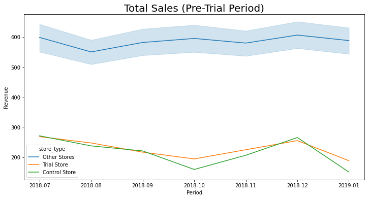

```python
# Plot sales by store type
plt.figure(figsize=(12, 6))
plt.title('Total Sales (Pre-Trial Period)', size=20)
sns.lineplot(data=pastSales, x='Period', y='Revenue', hue='store_type')
```

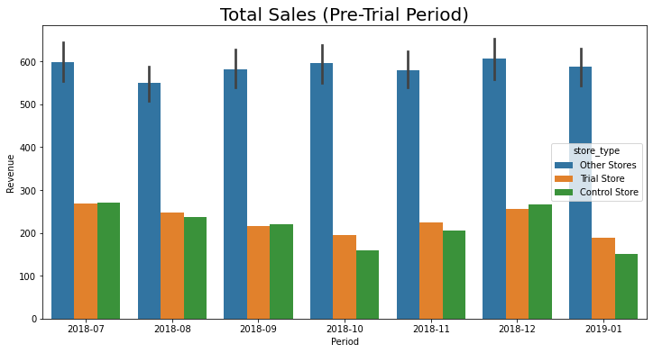

```python
# Plot sales by store type
plt.figure(figsize=(12, 6))
plt.title('Total Sales (Pre-Trial Period)', size=20)
sns.barplot(data=pastSales, x='Period', y='Revenue', hue='store_type')
```

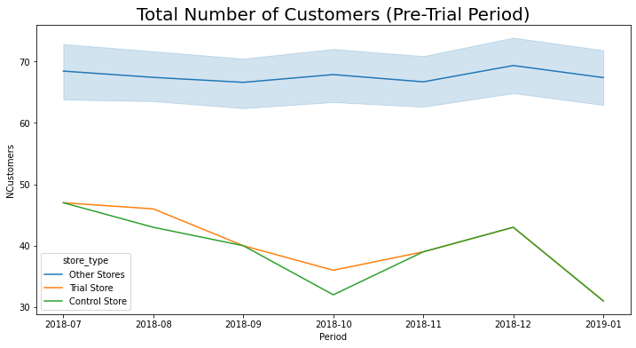

```python
# Plot sales by store type
plt.figure(figsize=(12, 6))
plt.title('Total Number of Customers (Pre-Trial Period)', size=20)
sns.lineplot(data=pastSales, x='Period', y='NCustomers', hue='store_type')
```

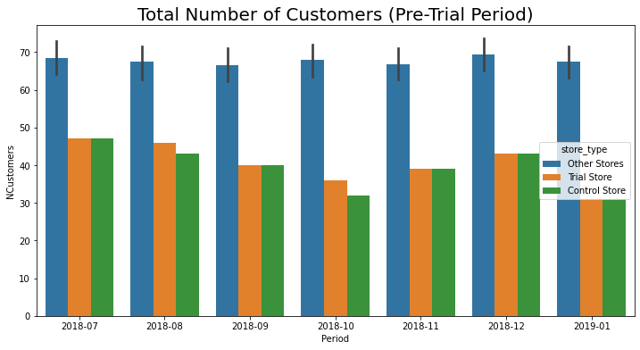

```python
# Plot sales by store type
plt.figure(figsize=(12, 6))
plt.title('Total Number of Customers (Pre-Trial Period)', size=20)
sns.barplot(data=pastSales, x='Period', y='NCustomers', hue='store_type')
```

From the above charts we can see how close the performance and trend of the control store and trail store are in the pre trail period. Store 233 will act as a suitable yard stick to evaluate how the changes in the trail store has affected sales. We move on to trial store 86

#### Trail store 86

```python
ShowControl(86)
```

| Trail | Control | scoreRevenue | scoreNCust | finalControlScore |
| --- | --- | --- | --- | --- |
| 86.0 | 155.0 | 0.772382 | 0.636309 | 0.704346 |

```python
# Create the df to plot from
pastSales = pastSalesdf(155, 86)
```

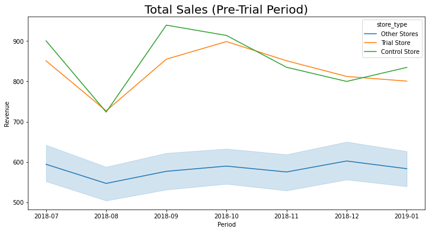

```python
# Plot sales by store type
plt.figure(figsize=(12, 6))
plt.title('Total Sales (Pre-Trial Period)', size=20)
sns.lineplot(data=pastSales, x='Period', y='Revenue', hue='store_type')
```

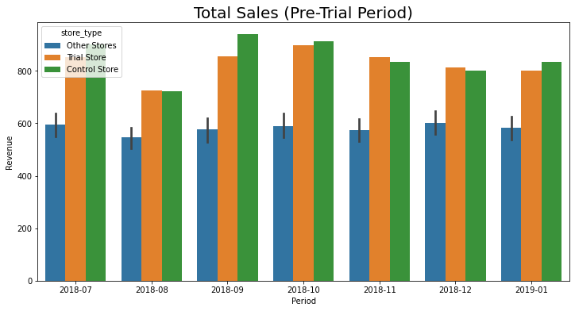

```python
# Plot sales by store type
plt.figure(figsize=(12, 6))
plt.title('Total Sales (Pre-Trial Period)', size=20)
sns.barplot(data=pastSales, x='Period', y='Revenue', hue='store_type')
```

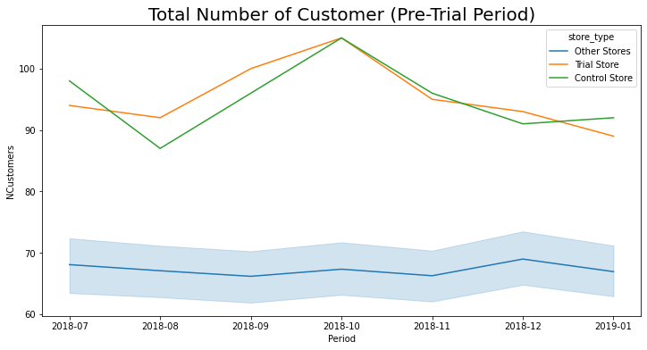

```python
# Plot sales by store type
plt.figure(figsize=(12, 6))
plt.title('Total Number of Customer (Pre-Trial Period)', size=20)
sns.lineplot(data=pastSales, x='Period', y='NCustomers', hue='store_type')
```

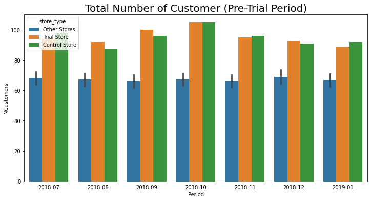

```python
# Plot sales by store type
plt.figure(figsize=(12, 6))
plt.title('Total Number of Customer (Pre-Trial Period)', size=20)
sns.barplot(data=pastSales, x='Period', y='NCustomers', hue='store_type')
```

Store 155 and store 86 have comparable performance and pass our visual test. We can confidently use store 155 as the control store for store 86

#### Trail Store 88

We follow the same steps as above to select a control store.

```python
ShowControl(88)
```

| Trail | Control | scoreRevenue | scoreNCust | finalControlScore |
| --- | --- | --- | --- | --- |
| 88.0 | 237.0 | 0.360413 | 0.812348 | 0.58638 |

```python
# Create the df to plot from
pastSales = pastSalesdf(237, 88)
```

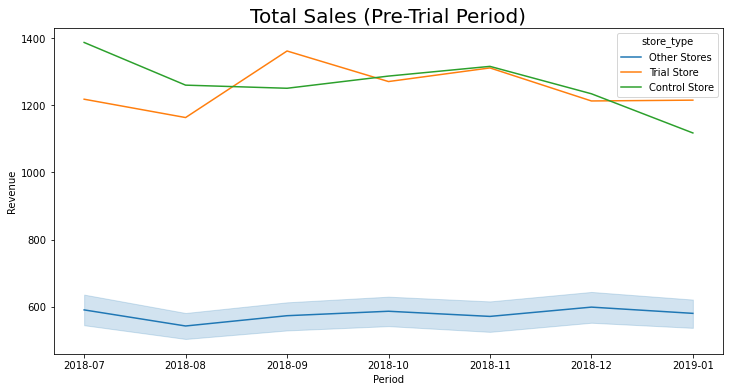

```python
# Plot sales by store type
plt.figure(figsize=(12, 6))
plt.title('Total Sales (Pre-Trial Period)', size=20)
sns.lineplot(data=pastSales, x='Period', y='Revenue', hue='store_type')
```

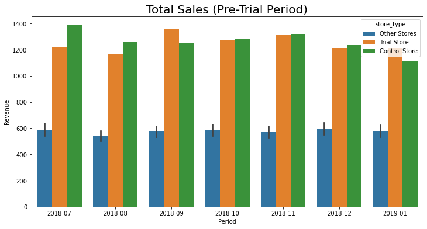

```python
# Plot sales by store type
plt.figure(figsize=(12, 6))
plt.title('Total Sales (Pre-Trial Period)', size=20)
sns.barplot(data=pastSales, x='Period', y='Revenue', hue='store_type')
```

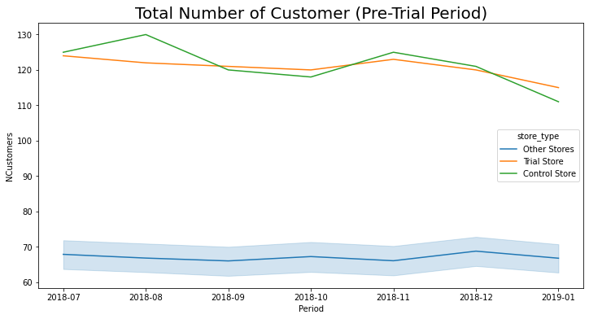

```python
# Plot sales by store type
plt.figure(figsize=(12, 6))
plt.title('Total Number of Customer (Pre-Trial Period)', size=20)
sns.lineplot(data=pastSales, x='Period', y='NCustomers', hue='store_type')
```

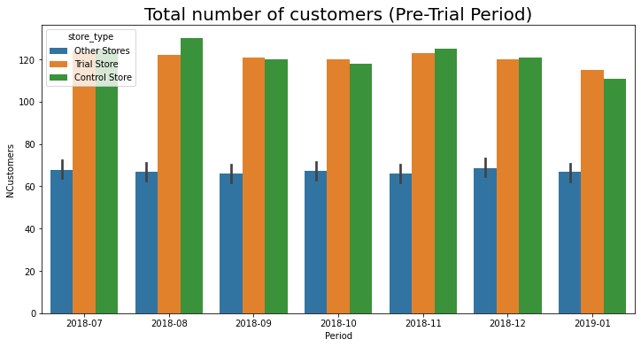

```python
# Plot sales by store type
plt.figure(figsize=(12, 6))
plt.title('Total number of customers (Pre-Trial Period)', size=20)
sns.barplot(data=pastSales, x='Period', y='NCustomers', hue='store_type')
```

For store 88 the control store performance does seem to mimic trend well enough to be considered a control store, we note small differences in absolute terms, we will control for this by scaling the absolute values later. Store 237 is selected as the control for store 88

### Assesment of the trial

Now that we have selected the control stores we will proceed to assessing the impact of the trial.

**Trail period:** The trial period goes from the start of February 2019 to end of April 2019.  
**Trail action:** New product layouts.  
**Trail objective:** Create an uplift in overall chip sales.

Now we asses if the changes have created an over uplift in sales.

#### Trial store 77

##### Sales

First, we need to work out a scaling factor to be applied to the control store. We compute this by dividing sum of 'Revenue' for trial store by sum of 'Revenue' for control store. This will give us sales scaled to a comparable level to account for any other variables. Let's call this variable 'scalingFactorSales'

```python
# Create the past sales df
pastSales = pastSalesdf(233, 77)
```

```python
# Create Scaling Factor for sales
trial_sum = pastSales.loc[pastSales['store_type']
                          == 'Trial Store', 'Revenue'].sum()
control_sum = pastSales.loc[pastSales['store_type']
                            == 'Control Store', 'Revenue'].sum()
scalingFactorSales = trial_sum / control_sum

# Create Scaling Factor for number of customers
trial_sum = pastSales.loc[pastSales['store_type']
                          == 'Trial Store', 'NCustomers'].sum()
control_sum = pastSales.loc[pastSales['store_type']
                            == 'Control Store', 'NCustomers'].sum()
scalingFactorCustomers = trial_sum / control_sum

# Debug
scalingFactorSales, scalingFactorCustomers
```

```
(1.0555739331789615, 1.0254545454545454)
```

Now that we know our scaling factor, we will scale the sales of the control store to a level comparable to the trail store pre trail sales.

```python
# Create the control sales dataframe
scaled_control = monthly_metrics.copy()

# Select only data of the control store
scaled_control = scaled_control.loc[scaled_control['Store'] == 233]

# Apply scaling by creating scaled Revenue
scaled_control['Scaled_Revenue'] = round(
    scaled_control['Revenue'] * scalingFactorSales, 1)

# Apply scaling by creating scaled NCustomers
scaled_control['Scaled_NCustomers'] = round(
    scaled_control['NCustomers'] * scalingFactorCustomers)

# Debug
scaled_control
```

|  | Store | Period | Revenue | NCustomers | ChipsPerCust | AvgPriceUnit | Scaled_Revenue | Scaled_NCustomers |
| --- | --- | --- | --- | --- | --- | --- | --- | --- |
| 2640 | 233 | 2018-07 | 271.2 | 47 | 1.680851 | 3.432911 | 286.3 | 48.0 |
| 2641 | 233 | 2018-08 | 237.7 | 43 | 1.558140 | 3.547761 | 250.9 | 44.0 |
| 2642 | 233 | 2018-09 | 220.9 | 40 | 1.700000 | 3.248529 | 233.2 | 41.0 |
| 2643 | 233 | 2018-10 | 159.3 | 32 | 1.500000 | 3.318750 | 168.2 | 33.0 |
| 2644 | 233 | 2018-11 | 206.5 | 39 | 1.564103 | 3.385246 | 218.0 | 40.0 |
| 2645 | 233 | 2018-12 | 265.4 | 43 | 1.627907 | 3.791429 | 280.1 | 44.0 |
| 2646 | 233 | 2019-01 | 150.5 | 31 | 1.322581 | 3.670732 | 158.9 | 32.0 |
| 2647 | 233 | 2019-02 | 220.7 | 42 | 1.523810 | 3.448438 | 233.0 | 43.0 |
| 2648 | 233 | 2019-03 | 180.6 | 35 | 1.485714 | 3.473077 | 190.6 | 36.0 |
| 2649 | 233 | 2019-04 | 144.2 | 27 | 1.518519 | 3.517073 | 152.2 | 28.0 |
| 2650 | 233 | 2019-05 | 289.1 | 53 | 1.471698 | 3.706410 | 305.2 | 54.0 |
| 2651 | 233 | 2019-06 | 197.0 | 34 | 1.529412 | 3.788462 | 207.9 | 35.0 |

Now lets calculate the percent difference between the control scaled sales and the trail store sales

```python
# Create a function that returns a dataframe with percent diff
def PctDiff(trail, metric):
    control = scaled_control[['Period', 'Scaled_{}'.format(metric)]]
    control.reset_index(drop=True, inplace=True)

    # Concatenate with trial store 'Revenue'
    trail = monthly_metrics.loc[monthly_metrics['Store'] == trail, metric]
    trail.reset_index(drop=True, inplace=True)

    final = pd.concat([control, trail], axis=1)
    final.columns = ['Period', 'Control{}'.format(
        metric), 'Trail{}'.format(metric)]
    final['percentageDiff'] = abs(final['Control{}'.format(
        metric)] - final['Trail{}'.format(metric)]) / final['Control{}'.format(metric)]
    return final
```

```python
# Take a look at the differance in sales
pctDiff = PctDiff(77, 'Revenue')
# Debug
pctDiff
```

|  | Period | ControlRevenue | TrailRevenue | percentageDiff |
| --- | --- | --- | --- | --- |
| 0 | 2018-07 | 286.3 | 268.4 | 0.062522 |
| 1 | 2018-08 | 250.9 | 247.5 | 0.013551 |
| 2 | 2018-09 | 233.2 | 216.8 | 0.070326 |
| 3 | 2018-10 | 168.2 | 194.3 | 0.155172 |
| 4 | 2018-11 | 218.0 | 224.9 | 0.031651 |
| 5 | 2018-12 | 280.1 | 255.2 | 0.088897 |
| 6 | 2019-01 | 158.9 | 188.4 | 0.185651 |
| 7 | 2019-02 | 233.0 | 211.6 | 0.091845 |
| 8 | 2019-03 | 190.6 | 255.1 | 0.338405 |
| 9 | 2019-04 | 152.2 | 258.1 | 0.695795 |
| 10 | 2019-05 | 305.2 | 257.1 | 0.157602 |
| 11 | 2019-06 | 207.9 | 246.6 | 0.186147 |

Now we have the absolute percent difference in sales of the trail and control store, since we have scaled these sales to the pre_trail level we expect that any difference to be influenced by other factors. Let’s visualise the percent difference column.

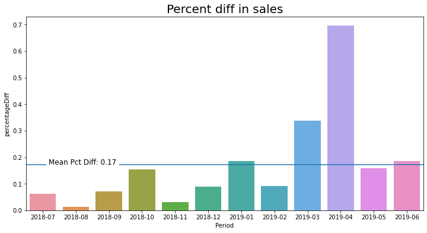

```python
# Plot sales by store type
plt.figure(figsize=(12, 6))
plt.title('Percent diff in sales', size=20)
sns.barplot(data=pctDiff, x='Period', y='percentageDiff')
mean = pctDiff.percentageDiff.mean()
plt.text(mean, mean, 'Mean Pct Diff: 0.17', fontsize=12,
         va='baseline', ha='left', backgroundcolor='w')
plt.axhline(mean)
```

From the above plot we can see that for the months of March 2019 and April 2019 sales seem to have shot up 34% and almost 70% respectively. This is much higher that the average percent difference of about 17 percent. From this we can preliminarily establish that yes in the period between 2019-02 - 2019-04 we note an impact on sales. But before we continue with the analysis we must establish if the difference is statistically significant.

Let’s use a T score to figure out how significant the results are.

We are testing the following:  
**Ho: The Pre-trail period is the same as the Trail period**  
**Ha: The Pre-trial period is different from the trail period**

```python
# Get the standard deviation of the percent diff for the pre-trial period
std_dev = pctDiff.loc[pctDiff.Period < '2019-02', 'percentageDiff'].std()
std_dev
```

```
0.06287335162304997
```

```python
# Lets calculate our DOF
print('We have {} Months in our pre-trial period'.format(
    len(pctDiff.loc[pctDiff.Period < '2019-02'])))
print('DOF: 7 - 1 = 6')
```

```
We have 7 Months in our pre-trial period
DOF: 7 - 1 = 6
```

```python
# We will test with a null hypothesis of there being 0 difference between trial and control stores
# Create a new column for 'tValue'
pctDiff['tValue'] = round((pctDiff['percentageDiff'] - 0) / std_dev, 2)
tscore = pctDiff.loc[(pctDiff['Period'] > '2019-01') &
                     (pctDiff['Period'] < '2019-05'), 'tValue']
tscore
```

```
7     1.46
8     5.38
9    11.07
Name: tValue, dtype: float64
```

```python
# Find the 95th percentile of the t distribution with dof = 6
t_95 = t.isf(0.05, 6)
print('The 95th percentile of the t distribution = {}'.format(round(t_95, 2)))
print('Is the T score higher than the 95th percentile?')
tscore > t_95
```

```
The 95th percentile of the t distribution = 1.94
Is the T score higher than the 95th percentile?
```

```
7    False
8     True
9     True
Name: tValue, dtype: bool
```

From the test we can conclude for the months of March and April 2019 the difference noted is statistically significant. Let’s visualise the results using a 95% confidence interval for the control sales.

```python
# Lets create a dataframe with sales of the control and trail store

# First lets clean up the date column to aid in ploting
pctDiff['Period'] = pctDiff['Period'].str.replace('-', '')
pctDiff['TransactionMonth'] = pd.to_datetime(pctDiff['Period'], format='%Y%m')

# Select data for the new dataframe
plot_diff = pctDiff[['TransactionMonth', 'ControlRevenue', 'TrailRevenue']]
plot_diff.set_index('TransactionMonth', inplace=True)
plot_diff[:2]
```

| TransactionMonth | ControlRevenue | TrailRevenue |
| --- | --- | --- |
| 2018-07-01 | 286.3 | 268.4 |
| 2018-08-01 | 250.9 | 247.5 |

```python
# Create two new columns the 5% and 95% confidence interval
plot_diff['Control 5% Confidence Interval'] = plot_diff['ControlRevenue'] * \
    (1 - std_dev*2)
plot_diff['Control 95% Confidence Interval'] = plot_diff['ControlRevenue'] * \
    (1 + std_dev*2)
plot_diff[:2]
```

| TransactionMonth | ControlRevenue | TrailRevenue | Control 5% Confidence Interval | Control 95% Confidence Interval |
| --- | --- | --- | --- | --- |
| 2018-07-01 | 286.3 | 268.4 | 250.298719 | 322.301281 |
| 2018-08-01 | 250.9 | 247.5 | 219.350152 | 282.449848 |

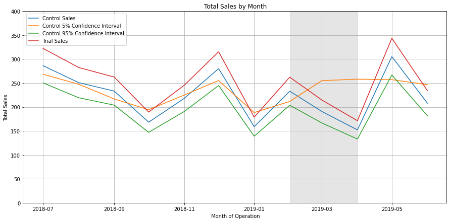

```python
# Lets plot revenue
# Set Size
plt.figure(figsize=(15, 7))
plt.plot(plot_diff)

# Set graph title and axis title
plt.title('Total Sales by Month')
plt.xlabel('Month of Operation')
plt.ylabel('Total Sales')
# Set legend
plt.legend(['Control Sales', 'Control 5% Confidence Interval',
            'Control 95% Confidence Interval', 'Trial Sales'], loc=2)
# Set new y-axis limit
plt.ylim((0, 400))
# Highlight trial period
plt.axvspan(*mdates.datestr2num(['2019-02-01',
                                 '2019-04-01']), color='grey', alpha=0.2)
# Set grid
plt.grid()
plt.show()
```

The results show that the sales for store 77 are significantly different from the control store in the trial period. The trial store performance lies outside the 5% and 95% confidence intervals in the two of the 3 trial months. We note some sort of delayed affect from the trial, do other stores behave the same? - We will see later.

Know that we can confidently say that there was an uplifting of sales due to new product layouts in store 77 - The natural question will be what were the drivers of this sales increase?

Did more customers buy chips than usual?  
Did customers buy more chips per transaction?  
Did the customers pay more per chip?

Lets investigate all these 3 drivers of sales.

##### Number of customers

We are interested in seeing if there is a statistically significant increase in the number of customers that made a purchase from the trail store in the trail period when compared to the control store. We will follow the same steps as we did for sales.

```python
# Create 'percentageDiff' dataframe
pctDiff = PctDiff(77, 'NCustomers')
# Debug
pctDiff
```

|  | Period | ControlNCustomers | TrailNCustomers | percentageDiff |
| --- | --- | --- | --- | --- |
| 0 | 2018-07 | 48.0 | 47 | 0.020833 |
| 1 | 2018-08 | 44.0 | 46 | 0.045455 |
| 2 | 2018-09 | 41.0 | 40 | 0.024390 |
| 3 | 2018-10 | 33.0 | 36 | 0.090909 |
| 4 | 2018-11 | 40.0 | 39 | 0.025000 |
| 5 | 2018-12 | 44.0 | 43 | 0.022727 |
| 6 | 2019-01 | 32.0 | 31 | 0.031250 |
| 7 | 2019-02 | 43.0 | 40 | 0.069767 |
| 8 | 2019-03 | 36.0 | 46 | 0.277778 |
| 9 | 2019-04 | 28.0 | 47 | 0.678571 |
| 10 | 2019-05 | 54.0 | 52 | 0.037037 |
| 11 | 2019-06 | 35.0 | 38 | 0.085714 |

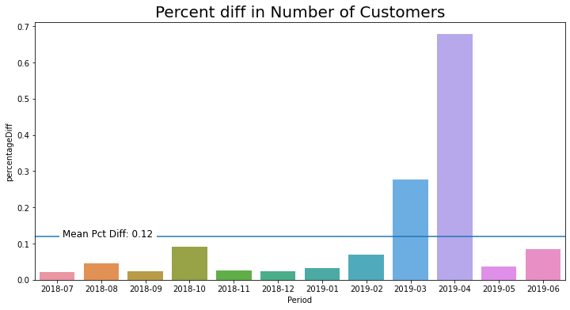

```python
# Plot Number of customer control vs trial
plt.figure(figsize=(12, 6))
plt.title('Percent diff in Number of Customers', size=20)
sns.barplot(data=pctDiff, x='Period', y='percentageDiff')
plt.axhline(round(pctDiff.percentageDiff.mean(), 2))
plt.text(0.118, 0.118, 'Mean Pct Diff: 0.12', fontsize=12,
         va='baseline', ha='left', backgroundcolor='w')
```

We can see that in the months of March and April registered a significant increase in the number of customers. Let's confirm if this difference is statistically significant using a 95% confidence interval

```python
# Get the standard deviation of the percent diff for the pre-trial period
std_dev = pctDiff.loc[pctDiff.Period < '2019-02', 'percentageDiff'].std()
std_dev
```

```
0.025094687570620368
```

```python
pctDiff[:1]
```

|  | Period | ControlNCustomers | TrailNCustomers | percentageDiff |
| --- | --- | --- | --- | --- |
| 0 | 2018-07 | 48.0 | 47 | 0.020833 |

```python
# Lets create a dataframe with number of customers of the control and trail store

# First lets clean up the date column to aid in ploting
pctDiff['Period'] = pctDiff['Period'].str.replace('-', '')
pctDiff['TransactionMonth'] = pd.to_datetime(pctDiff['Period'], format='%Y%m')

# Select data for the new dataframe
plot_diff = pctDiff[['TransactionMonth',
                     'ControlNCustomers', 'TrailNCustomers']]
plot_diff.set_index('TransactionMonth', inplace=True)
plot_diff[:2]
```

| TransactionMonth | ControlNCustomers | TrailNCustomers |
| --- | --- | --- |
| 2018-07-01 | 48.0 | 47 |
| 2018-08-01 | 44.0 | 46 |

```python
# Create two new columns the 5% and 95% confidence interval
plot_diff['Control 5% Confidence Interval'] = round(
    plot_diff['ControlNCustomers'] * (1 - std_dev*2))
plot_diff['Control 95% Confidence Interval'] = round(
    plot_diff['ControlNCustomers'] * (1 + std_dev*2))
plot_diff[:2]
```

| TransactionMonth | ControlNCustomers | TrailNCustomers | Control 5% Confidence Interval | Control 95% Confidence Interval |
| --- | --- | --- | --- | --- |
| 2018-07-01 | 48.0 | 47 | 46.0 | 50.0 |
| 2018-08-01 | 44.0 | 46 | 42.0 | 46.0 |

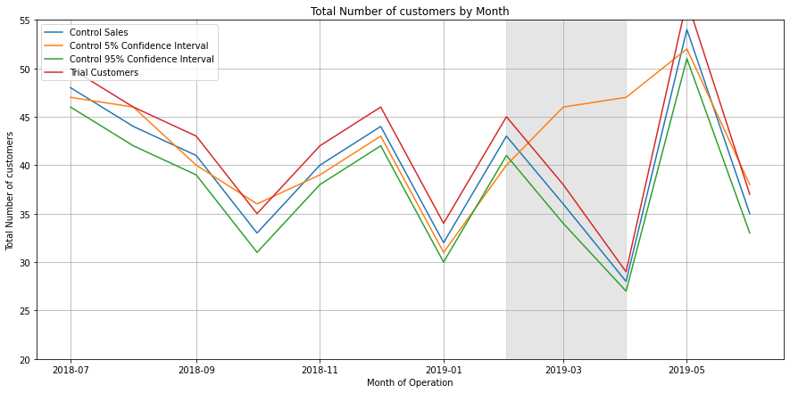

```python
# Lets plot Number of customers
# Set Size
plt.figure(figsize=(15, 7))
plt.plot(plot_diff)
# Set graph title and axis title
plt.title('Total Number of customers by Month')
plt.xlabel('Month of Operation')
plt.ylabel('Total Number of customers')
# Set legend
plt.legend(['Control Sales', 'Control 5% Confidence Interval',
            'Control 95% Confidence Interval', 'Trial Customers'], loc=2)
# Set new y-axis limit
plt.ylim((20, 55))
# Highlight trial period
plt.axvspan(*mdates.datestr2num(['2019-02-01',
                                 '2019-04-01']), color='grey', alpha=0.2)
# Set grid
plt.grid()
plt.show()
```

We do note a statistically significant increase in the number of customers in march and april. What about the price paid and quantity?

##### Chips per Customer & Average price per unit

###### Chips per customer

We are interested in figuring out if the trail has any statistically significant affect in the number of chips each customer bought. We will use a two sample T-test to compare the mean of the chips per customer metric to determine if they are different.

We are testing the following:  
**Ho: ChipsPerCust metric is the same for trail store and control store**  
**Ha: ChipsPerCust metric is not the same for trail store and control store**

```python
# Create a dataframe for calculations
x = monthly_metrics.loc[monthly_metrics.Store.isin(
    [77, 233]), ['Period', 'Store', 'ChipsPerCust', 'AvgPriceUnit']]
x = x[x.Period < '2019-05']
x['period_type'] = np.where((x.Period >= '2019-02')
                            & (x.Period <= '2019-04'), 'Trail', 'Pre-trial')
x.sample(3)
```

|  | Period | Store | ChipsPerCust | AvgPriceUnit | period_type |
| --- | --- | --- | --- | --- | --- |
| 2640 | 2018-07 | 233 | 1.680851 | 3.432911 | Pre-trial |
| 866 | 2018-09 | 77 | 1.650000 | 3.284848 | Pre-trial |
| 865 | 2018-08 | 77 | 1.543478 | 3.485915 | Pre-trial |

```python
# Test independence of samples (Chip/Customer trail vs control)
a = x.loc[(x.Store == 233) & (x.period_type == 'Trail'), 'ChipsPerCust']
b = x.loc[(x.Store == 77) & (x.period_type == 'Trail'), 'ChipsPerCust']

# Calculate p value
t, p = ttest_ind(a, b)

# Print Pvalue
print('The probability that the two samples come from the same distribution is: {}%'.format(
    round(p * 100, 4)))
```

```
The probability that the two samples come from the same distribution is: 0.2556%
```

Our pvalue is less than the 5% alpha thus indicating we can reject the null hypothesis and assume the alternative that the chips per customer metric is different for both groups. Lets look at the distribution to inspect how different they are.

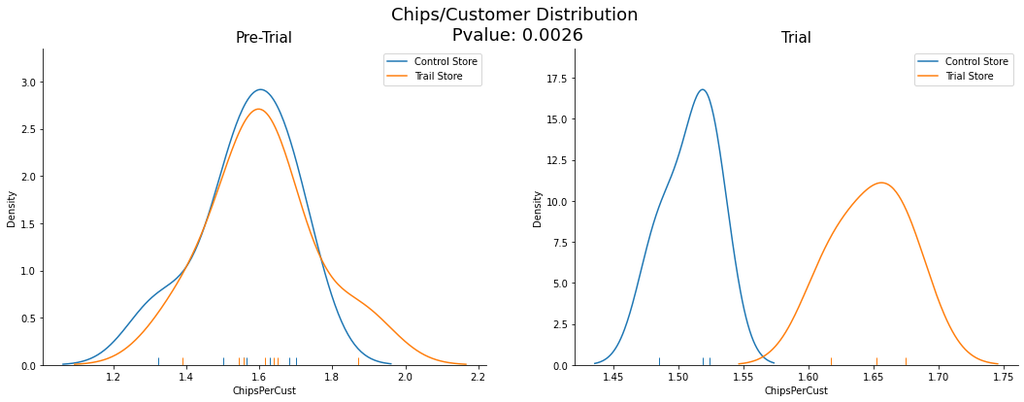

```python
# Lets visualise the distributions.
# Set up the chart
fig, axes = plt.subplots(1, 2, figsize=(18, 6), sharey=False)
fig.suptitle(
    'Chips/Customer Distribution\n Pvalue: {}'.format(round(p, 4)), size=18)

# Pre Trial
sns.distplot(ax=axes[0], a=x.loc[(x.Store == 233) & (
    x.period_type == 'Pre-trial'), 'ChipsPerCust'], hist=False, rug=True, label='Control Store')
sns.distplot(ax=axes[0], a=x.loc[(x.Store == 77) & (
    x.period_type == 'Pre-trial'), 'ChipsPerCust'], hist=False, rug=True, label='Trail Store')
sns.despine()
axes[0].legend()
axes[0].set_title('Pre-Trial', size=15)

# Trail
sns.distplot(ax=axes[1], a=x.loc[(x.Store == 233) & (
    x.period_type == 'Trail'), 'ChipsPerCust'], hist=False, rug=True, label='Control Store')
sns.distplot(ax=axes[1], a=x.loc[(x.Store == 77) & (
    x.period_type == 'Trail'), 'ChipsPerCust'], hist=False, rug=True, label='Trial Store')
sns.despine()
axes[1].legend()
axes[1].set_title('Trial', size=15)
```

We note that the trail store has significantly higher chips per customer metric. This means that each customer is buying on average more chips and is a driving factor for the increase in sales by the trail store during the trail period.

Let's look at the average price per unit metric.

##### Average price per unit

Lets test as we did for the chips per customer if the samples are independent @ alpha 0.05.

```python
# Test independence of samples (Average Price per Unit trail vs control)
a = x.loc[(x.Store == 233) & (x.period_type == 'Trail'), 'AvgPriceUnit']
b = x.loc[(x.Store == 77) & (x.period_type == 'Trail'), 'AvgPriceUnit']

# Calculate p value
t, p = ttest_ind(a, b)

# Print Pvalue
print('The probability that the two samples come from the same distribution is: {}%'.format(
    round(p * 100, 3)))
```

```
The probability that the two samples come from the same distribution is: 8.237%
```

In terms of average price we don’t have enough evidence to conclude that the samples are statistically different so there would be no point in looking for a difference.

Let’s do the same to asses the impact of the trial on store 86.

#### Trail Store 86

##### Sales

```python
# Create the past sales df
pastSales = pastSalesdf(155, 86)
```

```python
# Create Scaling Factor for sales
trial_sum = pastSales.loc[pastSales['store_type']
                          == 'Trial Store', 'Revenue'].sum()
control_sum = pastSales.loc[pastSales['store_type']
                            == 'Control Store', 'Revenue'].sum()
scalingFactorSales = trial_sum / control_sum

# Create Scaling Factor for number of customers
trial_sum = pastSales.loc[pastSales['store_type']
                          == 'Trial Store', 'NCustomers'].sum()
control_sum = pastSales.loc[pastSales['store_type']
                            == 'Control Store', 'NCustomers'].sum()
scalingFactorCustomers = trial_sum / control_sum

# Debug
scalingFactorSales, scalingFactorCustomers
```

```
(0.9745010340826932, 1.0045112781954888)
```

```python
# Create the control sales dataframe
scaled_control = monthly_metrics.copy()

# Select only data of the control store
scaled_control = scaled_control.loc[scaled_control['Store'] == 155]

# Apply scaling by creating scaled Revenue
scaled_control['Scaled_Revenue'] = round(
    scaled_control['Revenue'] * scalingFactorSales, 1)

# Apply scaling by creating scaled NCustomers
scaled_control['Scaled_NCustomers'] = round(
    scaled_control['NCustomers'] * scalingFactorCustomers)
# Debug
scaled_control
```

|  | Store | Period | Revenue | NCustomers | ChipsPerCust | AvgPriceUnit | Scaled_Revenue | Scaled_NCustomers |
| --- | --- | --- | --- | --- | --- | --- | --- | --- |
| 1764 | 155 | 2018-07 | 900.60 | 98 | 2.448980 | 3.752500 | 877.6 | 98.0 |
| 1765 | 155 | 2018-08 | 723.70 | 87 | 2.425287 | 3.429858 | 705.2 | 87.0 |
| 1766 | 155 | 2018-09 | 939.60 | 96 | 2.729167 | 3.586260 | 915.6 | 96.0 |
| 1767 | 155 | 2018-10 | 914.00 | 105 | 2.438095 | 3.570312 | 890.7 | 105.0 |
| 1768 | 155 | 2018-11 | 835.00 | 96 | 2.583333 | 3.366935 | 813.7 | 96.0 |
| 1769 | 155 | 2018-12 | 799.80 | 91 | 2.483516 | 3.538938 | 779.4 | 91.0 |
| 1770 | 155 | 2019-01 | 834.60 | 92 | 2.565217 | 3.536441 | 813.3 | 92.0 |
| 1771 | 155 | 2019-02 | 850.80 | 92 | 2.586957 | 3.574790 | 829.1 | 92.0 |
| 1772 | 155 | 2019-03 | 767.00 | 91 | 2.461538 | 3.424107 | 747.4 | 91.0 |
| 1773 | 155 | 2019-04 | 800.40 | 93 | 2.451613 | 3.510526 | 780.0 | 93.0 |
| 1774 | 155 | 2019-05 | 836.25 | 101 | 2.366337 | 3.498954 | 814.9 | 101.0 |
| 1775 | 155 | 2019-06 | 760.80 | 87 | 2.459770 | 3.555140 | 741.4 | 87.0 |

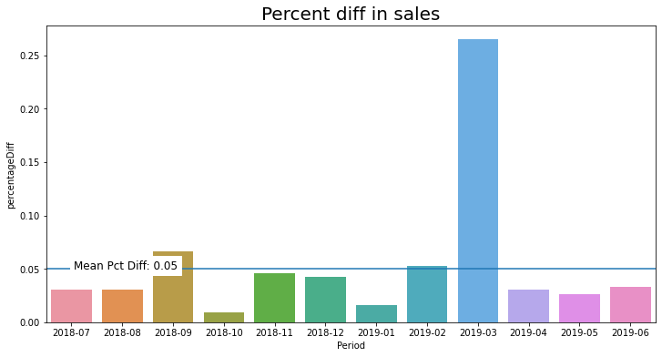

```python
# Create the df to plot from
pctDiff = PctDiff(86, 'Revenue')

# Plot Number of customer control vs trial
plt.figure(figsize=(12, 6))
plt.title('Percent diff in sales', size=20)
sns.barplot(data=pctDiff, x='Period', y='percentageDiff')
mean = round(pctDiff.percentageDiff.mean(), 2)
plt.axhline(mean)
plt.text(mean, mean, 'Mean Pct Diff: 0.05',
         fontsize=12, ha='left', backgroundcolor='w')
```

```python
# Get the standard deviation of the percent diff for the pre-trial period
std_dev = pctDiff.loc[pctDiff.Period < '2019-02', 'percentageDiff'].std()
std_dev
```

```
0.01927670872864864
```

```python
# Lets create a dataframe with sales of the control and trail store
# First lets clean up the date column to aid in ploting
pctDiff['Period'] = pctDiff['Period'].str.replace('-', '')
pctDiff['TransactionMonth'] = pd.to_datetime(pctDiff['Period'], format='%Y%m')

# Select data for the new dataframe
plot_diff = pctDiff[['TransactionMonth', 'ControlRevenue', 'TrailRevenue']]
plot_diff.set_index('TransactionMonth', inplace=True)

# Create two new columns the 5% and 95% confidence interval
plot_diff['Control 5% Confidence Interval'] = round(
    plot_diff['ControlRevenue'] * (1 - std_dev*2))
plot_diff['Control 95% Confidence Interval'] = round(
    plot_diff['ControlRevenue'] * (1 + std_dev*2))
plot_diff[:2]
```

| TransactionMonth | ControlRevenue | TrailRevenue | Control 5% Confidence Interval | Control 95% Confidence Interval |
| --- | --- | --- | --- | --- |
| 2018-07-01 | 877.6 | 851.00 | 844.0 | 911.0 |
| 2018-08-01 | 705.2 | 726.85 | 678.0 | 732.0 |

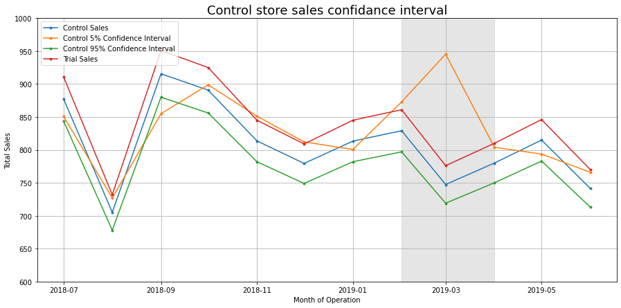

```python
# Lets plot sales
# Set Size
plt.figure(figsize=(15, 7))
plt.plot(plot_diff, marker='.')

# Set graph title and axis title
plt.title('Control store sales confidance interval', size=18)
plt.xlabel('Month of Operation')
plt.ylabel('Total Sales')

# Set legend
plt.legend(['Control Sales', 'Control 5% Confidence Interval',
            'Control 95% Confidence Interval', 'Trial Sales'], loc=2)

# Set new y-axis limit
plt.ylim((600, 1000))
# Highlight trial period
plt.axvspan(*mdates.datestr2num(['2019-02-01',
                                 '2019-04-01']), color='grey', alpha=0.2)
# Set grid
plt.grid()
plt.show()
```

##### Customers

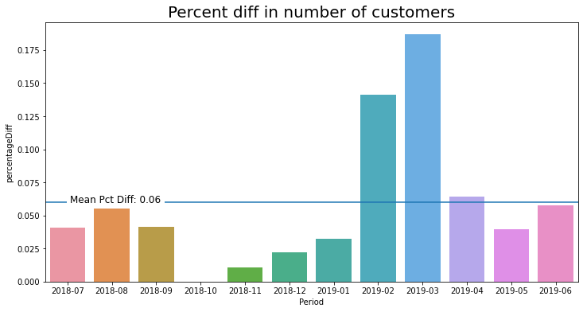

```python
# Create the df to plot from
pctDiff = PctDiff(86, 'NCustomers')

# Plot Number of customer control vs trial
plt.figure(figsize=(12, 6))
plt.title('Percent diff in number of customers', size=20)
sns.barplot(data=pctDiff, x='Period', y='percentageDiff')
mean = round(pctDiff.percentageDiff.mean(), 2)
plt.axhline(mean)
plt.text(mean, mean, 'Mean Pct Diff: {}'.format(mean),
         fontsize=12, ha='left', backgroundcolor='w')
```

```python
# Get the standard deviation of the percent diff for the pre-trial period
std_dev = pctDiff.loc[pctDiff.Period < '2019-02', 'percentageDiff'].std()
std_dev
```

```
0.019827617813781905
```

```python
# Lets create a dataframe with sales of the control and trail store

# First lets clean up the date column to aid in ploting
pctDiff['Period'] = pctDiff['Period'].str.replace('-', '')
pctDiff['TransactionMonth'] = pd.to_datetime(pctDiff['Period'], format='%Y%m')

# Select data for the new dataframe
plot_diff = pctDiff[['TransactionMonth',
                     'ControlNCustomers', 'TrailNCustomers']]
plot_diff.set_index('TransactionMonth', inplace=True)

# Create two new columns the 5% and 95% confidence interval
plot_diff['Control 5% Confidence Interval'] = round(
    plot_diff['ControlNCustomers'] * (1 - std_dev*2))
plot_diff['Control 95% Confidence Interval'] = round(
    plot_diff['ControlNCustomers'] * (1 + std_dev*2))
plot_diff[:2]
```

| TransactionMonth | ControlNCustomers | TrailNCustomers | Control 5% Confidence Interval | Control 95% Confidence Interval |
| --- | --- | --- | --- | --- |
| 2018-07-01 | 98.0 | 94 | 94.0 | 102.0 |
| 2018-08-01 | 87.0 | 92 | 84.0 | 90.0 |

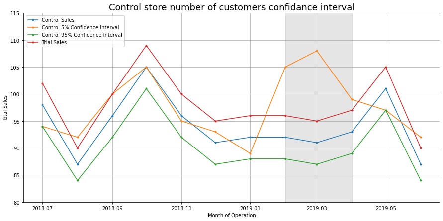

```python
# Lets plot sales
# Set Size
plt.figure(figsize=(15, 7))
plt.plot(plot_diff, marker='.')

# Set graph title and axis title
plt.title('Control store number of customers confidance interval', size=18)
plt.xlabel('Month of Operation')
plt.ylabel('Total Sales')

# Set legend
plt.legend(['Control Sales', 'Control 5% Confidence Interval',
            'Control 95% Confidence Interval', 'Trial Sales'], loc=2)
# Set new y-axis limit
plt.ylim((80, 115))
# Highlight trial period
plt.axvspan(*mdates.datestr2num(['2019-02-01',
                                 '2019-04-01']), color='grey', alpha=0.2)
# Set grid
plt.grid()
plt.show()
```

##### Chips per Customer & Average price per unit

###### Chips per customer

```python
# Create a dataframe for calculations
x = monthly_metrics.loc[monthly_metrics.Store.isin(
    [86, 155]), ['Period', 'Store', 'ChipsPerCust', 'AvgPriceUnit']]
x = x[x.Period < '2019-05']
x['period_type'] = np.where((x.Period >= '2019-02')
                            & (x.Period <= '2019-04'), 'Trail', 'Pre-trial')
x.sample(3)
```

|  | Period | Store | ChipsPerCust | AvgPriceUnit | period_type |
| --- | --- | --- | --- | --- | --- |
| 1769 | 2018-12 | 155 | 2.483516 | 3.538938 | Pre-trial |
| 1765 | 2018-08 | 155 | 2.425287 | 3.429858 | Pre-trial |
| 1773 | 2019-04 | 155 | 2.451613 | 3.510526 | Trail |

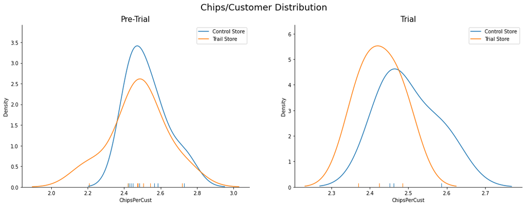

```python
# Lets visualise the distributions.
# Set up the chart
fig, axes = plt.subplots(1, 2, figsize=(18, 6), sharey=False)
fig.suptitle('Chips/Customer Distribution', size=18)

# Pre Trial
sns.distplot(ax=axes[0], a=x.loc[(x.Store == 155) & (
    x.period_type == 'Pre-trial'), 'ChipsPerCust'], hist=False, rug=True, label='Control Store')
sns.distplot(ax=axes[0], a=x.loc[(x.Store == 86) & (
    x.period_type == 'Pre-trial'), 'ChipsPerCust'], hist=False, rug=True, label='Trail Store')
sns.despine()
axes[0].legend()
axes[0].set_title('Pre-Trial', size=15)

# Trail
sns.distplot(ax=axes[1], a=x.loc[(x.Store == 155) & (
    x.period_type == 'Trail'), 'ChipsPerCust'], hist=False, rug=True, label='Control Store')
sns.distplot(ax=axes[1], a=x.loc[(x.Store == 86) & (
    x.period_type == 'Trail'), 'ChipsPerCust'], hist=False, rug=True, label='Trial Store')
sns.despine()
axes[1].legend()
axes[1].set_title('Trial', size=15)
```

From the above distributions we can see that the trail in store 86 has little affect on the number of chips each customer bought. It looks like the during the trial customers bought slightly less chips. What about the average price paid ?

##### Average Price per chip

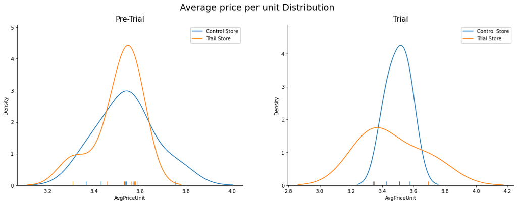

```python
# Lets visualise the distributions.
# Set up the chart
fig, axes = plt.subplots(1, 2, figsize=(18, 6), sharey=False)
fig.suptitle('Average price per unit Distribution', size=18)

# Pre Trial
sns.distplot(ax=axes[0], a=x.loc[(x.Store == 155) & (
    x.period_type == 'Pre-trial'), 'AvgPriceUnit'], hist=False, rug=True, label='Control Store')
sns.distplot(ax=axes[0], a=x.loc[(x.Store == 86) & (
    x.period_type == 'Pre-trial'), 'AvgPriceUnit'], hist=False, rug=True, label='Trail Store')
sns.despine()
axes[0].legend()
axes[0].set_title('Pre-Trial', size=15)

# Trail
sns.distplot(ax=axes[1], a=x.loc[(x.Store == 155) & (
    x.period_type == 'Trail'), 'AvgPriceUnit'], hist=False, rug=True, label='Control Store')
sns.distplot(ax=axes[1], a=x.loc[(x.Store == 86) & (
    x.period_type == 'Trail'), 'AvgPriceUnit'], hist=False, rug=True, label='Trial Store')
sns.despine()
axes[1].legend()
axes[1].set_title('Trial', size=15)
```

```python
# Test independence of samples (Average price trail vs control)
a = x.loc[(x.Store == 155) & (x.period_type == 'Trail'), 'AvgPriceUnit']
b = x.loc[(x.Store == 86) & (x.period_type == 'Trail'), 'AvgPriceUnit']
# Calculate p value
t, p = ttest_ind(a, b)
# Print Pvalue
print('The probability that the two samples come from the same distribution is: {}%'.format(
    round(p * 100, 4)))
```

```
The probability that the two samples come from the same distribution is: 75.7362%
```

#### Trail Store 88

##### Sales

```python
# Create the df to plot from
pastSales = pastSalesdf(237, 88)
```

```python
# Create Scaling Factor for sales
trial_sum = pastSales.loc[pastSales['store_type']
                          == 'Trial Store', 'Revenue'].sum()
control_sum = pastSales.loc[pastSales['store_type']
                            == 'Control Store', 'Revenue'].sum()
scalingFactorSales = trial_sum / control_sum

# Create Scaling Factor for number of customers
trial_sum = pastSales.loc[pastSales['store_type']
                          == 'Trial Store', 'NCustomers'].sum()
control_sum = pastSales.loc[pastSales['store_type']
                            == 'Control Store', 'NCustomers'].sum()
scalingFactorCustomers = trial_sum / control_sum

# Debug
scalingFactorSales, scalingFactorCustomers
```

```
(0.9888064337591638, 0.9941176470588236)
```

```python
# Create the control sales dataframe
scaled_control = monthly_metrics.copy()
# Select only data of the control store
scaled_control = scaled_control.loc[scaled_control['Store'] == 237]
# Apply scaling by creating scaled Revenue
scaled_control['Scaled_Revenue'] = round(
    scaled_control['Revenue'] * scalingFactorSales, 1)
# Apply scaling by creating scaled NCustomers
scaled_control['Scaled_NCustomers'] = round(
    scaled_control['NCustomers'] * scalingFactorCustomers)
# Debug
scaled_control
```

|  | Store | Period | Revenue | NCustomers | ChipsPerCust | AvgPriceUnit | Scaled_Revenue | Scaled_NCustomers |
| --- | --- | --- | --- | --- | --- | --- | --- | --- |
| 2688 | 237 | 2018-07 | 1387.2 | 125 | 2.496000 | 4.446154 | 1371.7 | 124.0 |
| 2689 | 237 | 2018-08 | 1260.1 | 130 | 2.253846 | 4.300683 | 1246.0 | 129.0 |
| 2690 | 237 | 2018-09 | 1250.8 | 120 | 2.375000 | 4.388772 | 1236.8 | 119.0 |
| 2691 | 237 | 2018-10 | 1287.1 | 118 | 2.432203 | 4.484669 | 1272.7 | 117.0 |
| 2692 | 237 | 2018-11 | 1316.0 | 125 | 2.432000 | 4.328947 | 1301.3 | 124.0 |
| 2693 | 237 | 2018-12 | 1234.4 | 121 | 2.338843 | 4.361837 | 1220.6 | 120.0 |
| 2694 | 237 | 2019-01 | 1117.7 | 111 | 2.315315 | 4.349027 | 1105.2 | 110.0 |
| 2695 | 237 | 2019-02 | 1313.0 | 119 | 2.487395 | 4.435811 | 1298.3 | 118.0 |
| 2696 | 237 | 2019-03 | 1177.6 | 116 | 2.310345 | 4.394030 | 1164.4 | 115.0 |
| 2697 | 237 | 2019-04 | 1153.6 | 116 | 2.258621 | 4.403053 | 1140.7 | 115.0 |
| 2698 | 237 | 2019-05 | 1127.9 | 122 | 2.114754 | 4.371705 | 1115.3 | 121.0 |
| 2699 | 237 | 2019-06 | 1143.4 | 118 | 2.203390 | 4.397692 | 1130.6 | 117.0 |

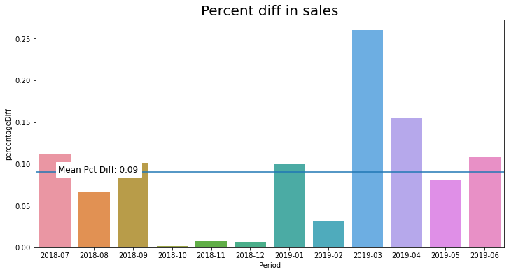

```python
# Create the df to plot from
pctDiff = PctDiff(88, 'Revenue')
# Plot Number of customer control vs trial
plt.figure(figsize=(12, 6))
plt.title('Percent diff in sales', size=20)
sns.barplot(data=pctDiff, x='Period', y='percentageDiff')
mean = round(pctDiff.percentageDiff.mean(), 2)
plt.axhline(mean)
plt.text(mean, mean, 'Mean Pct Diff: {}'.format(mean),
         fontsize=12, ha='left', backgroundcolor='w')
```

```python
# Get the standard deviation of the percent diff for the pre-trial period
std_dev = pctDiff.loc[pctDiff.Period < '2019-02', 'percentageDiff'].std()
std_dev
```

```
0.04990709679756428
```

```python
# Lets create a dataframe with sales of the control and trail store
# First lets clean up the date column to aid in ploting
pctDiff['Period'] = pctDiff['Period'].str.replace('-', '')
pctDiff['TransactionMonth'] = pd.to_datetime(pctDiff['Period'], format='%Y%m')
# Select data for the new dataframe
plot_diff = pctDiff[['TransactionMonth', 'ControlRevenue', 'TrailRevenue']]
plot_diff.set_index('TransactionMonth', inplace=True)
# Create two new columns the 5% and 95% confidence interval
plot_diff['Control 5% Confidence Interval'] = round(
    plot_diff['ControlRevenue'] * (1 - std_dev*2))
plot_diff['Control 95% Confidence Interval'] = round(
    plot_diff['ControlRevenue'] * (1 + std_dev*2))
plot_diff[:2]
```

| TransactionMonth | ControlRevenue | TrailRevenue | Control 5% Confidence Interval | Control 95% Confidence Interval |
| --- | --- | --- | --- | --- |
| 2018-07-01 | 1371.7 | 1218.2 | 1235.0 | 1509.0 |
| 2018-08-01 | 1246.0 | 1163.6 | 1122.0 | 1370.0 |

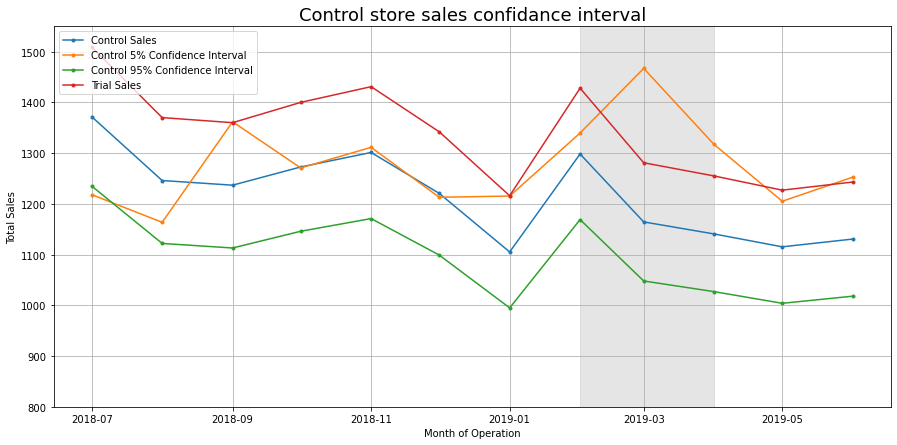

```python
# Lets plot sales
# Set Size
plt.figure(figsize=(15, 7))
plt.plot(plot_diff, marker='.')
# Set graph title and axis title
plt.title('Control store sales confidance interval', size=18)
plt.xlabel('Month of Operation')
plt.ylabel('Total Sales')
# Set legend
plt.legend(['Control Sales', 'Control 5% Confidence Interval',
            'Control 95% Confidence Interval', 'Trial Sales'], loc=2)
# Set new y-axis limit
plt.ylim((800, 1550))
# Highlight trial period
plt.axvspan(*mdates.datestr2num(['2019-02-01',
                                 '2019-04-01']), color='grey', alpha=0.2)
# Set grid
plt.grid()
plt.show()
```

Let’s have a look at assessing this for number of customers as well.

##### Customers

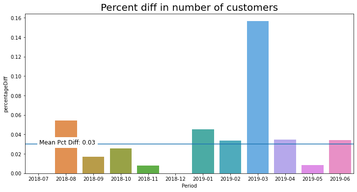

```python
# Create the df to plot from
pctDiff = PctDiff(88, 'NCustomers')
# Plot Number of customer control vs trial
plt.figure(figsize=(12, 6))
plt.title('Percent diff in number of customers', size=20)
sns.barplot(data=pctDiff, x='Period', y='percentageDiff')
mean = round(pctDiff.percentageDiff.mean(), 2)
plt.axhline(mean)
plt.text(mean, mean, 'Mean Pct Diff: {}'.format(mean),
         fontsize=12, ha='left', backgroundcolor='w')
```

```python
# Get the standard deviation of the percent diff for the pre-trial period
std_dev = pctDiff.loc[pctDiff.Period < '2019-02', 'percentageDiff'].std()
std_dev
```

```
0.0215694548094733
```

```python
# Lets create a dataframe with sales of the control and trail store

# First lets clean up the date column to aid in ploting
pctDiff['Period'] = pctDiff['Period'].str.replace('-', '')
pctDiff['TransactionMonth'] = pd.to_datetime(pctDiff['Period'], format='%Y%m')

# Select data for the new dataframe
plot_diff = pctDiff[['TransactionMonth',
                     'ControlNCustomers', 'TrailNCustomers']]
plot_diff.set_index('TransactionMonth', inplace=True)

# Create two new columns the 5% and 95% confidence interval
plot_diff['Control 5% Confidence Interval'] = round(
    plot_diff['ControlNCustomers'] * (1 - std_dev*2))
plot_diff['Control 95% Confidence Interval'] = round(
    plot_diff['ControlNCustomers'] * (1 + std_dev*2))
plot_diff[:2]
```

| TransactionMonth | ControlNCustomers | TrailNCustomers | Control 5% Confidence Interval | Control 95% Confidence Interval |
| --- | --- | --- | --- | --- |
| 2018-07-01 | 124.0 | 124 | 119.0 | 129.0 |
| 2018-08-01 | 129.0 | 122 | 123.0 | 135.0 |

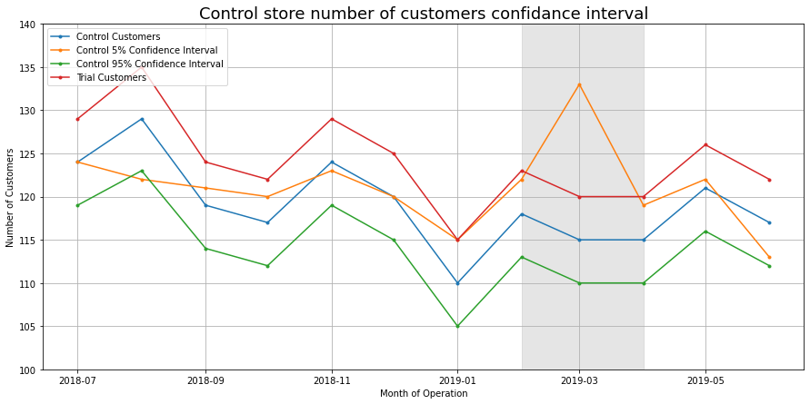

```python
# Lets plot sales
# Set Size
plt.figure(figsize=(15, 7))
plt.plot(plot_diff, marker='.')
# Set graph title and axis title
plt.title('Control store number of customers confidance interval', size=18)
plt.xlabel('Month of Operation')
plt.ylabel('Number of Customers')
# Set legend
plt.legend(['Control Customers', 'Control 5% Confidence Interval',
            'Control 95% Confidence Interval', 'Trial Customers'], loc=2)
# Set new y-axis limit
plt.ylim((100, 140))
# Highlight trial period
plt.axvspan(*mdates.datestr2num(['2019-02-01',
                                 '2019-04-01']), color='grey', alpha=0.2)
# Set grid
plt.grid()
plt.show()
```

We see that the increase in the number of customers was statistically significant in the month of march, we must note that for the months of February and April the difference was at the high end of the confidence interval. It looks like the increase of sales registered in March was due to the increase in customers. Let us confirm if chips per customer and average price per unit had a role to play.

##### Chips per Customer & Average price per unit

###### Chips per customer

```python
# Create a dataframe for calculations
x = monthly_metrics.loc[monthly_metrics.Store.isin(
    [88, 237]), ['Period', 'Store', 'ChipsPerCust', 'AvgPriceUnit']]
x = x[x.Period < '2019-05']
x['period_type'] = np.where((x.Period >= '2019-02')
                            & (x.Period <= '2019-04'), 'Trail', 'Pre-trial')
x.sample(3)
```

|  | Period | Store | ChipsPerCust | AvgPriceUnit | period_type |
| --- | --- | --- | --- | --- | --- |
| 990 | 2019-01 | 88 | 2.452174 | 4.309929 | Pre-trial |
| 2697 | 2019-04 | 237 | 2.258621 | 4.403053 | Trail |
| 984 | 2018-07 | 88 | 2.322581 | 4.229861 | Pre-trial |

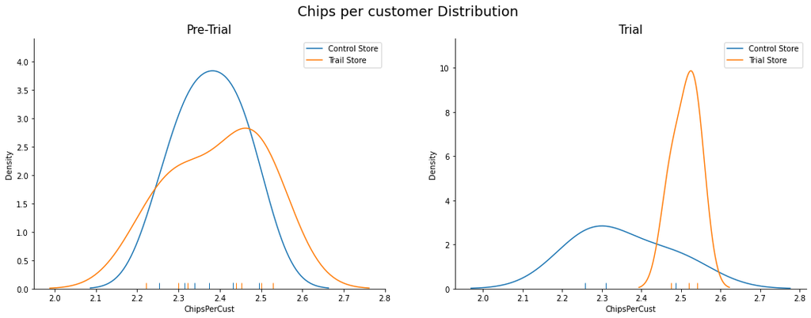

```python
# Lets visualise the distributions.
# Set up the chart
fig, axes = plt.subplots(1, 2, figsize=(18, 6), sharey=False)
fig.suptitle('Chips per customer Distribution', size=18)

# Pre Trial
sns.distplot(ax=axes[0], a=x.loc[(x.Store == 237) & (
    x.period_type == 'Pre-trial'), 'ChipsPerCust'], hist=False, rug=True, label='Control Store')
sns.distplot(ax=axes[0], a=x.loc[(x.Store == 88) & (
    x.period_type == 'Pre-trial'), 'ChipsPerCust'], hist=False, rug=True, label='Trail Store')
sns.despine()
axes[0].legend()
axes[0].set_title('Pre-Trial', size=15)

# Trail
sns.distplot(ax=axes[1], a=x.loc[(x.Store == 237) & (
    x.period_type == 'Trail'), 'ChipsPerCust'], hist=False, rug=True, label='Control Store')
sns.distplot(ax=axes[1], a=x.loc[(x.Store == 88) & (
    x.period_type == 'Trail'), 'ChipsPerCust'], hist=False, rug=True, label='Trial Store')
sns.despine()
axes[1].legend()
axes[1].set_title('Trial', size=15)
```

```python
# Test independence of samples (Chip/Customer trail vs control)
a = x.loc[(x.Store == 237) & (x.period_type == 'Trail'), 'ChipsPerCust']
b = x.loc[(x.Store == 88) & (x.period_type == 'Trail'), 'ChipsPerCust']
# Calculate p value
t, p = ttest_ind(a, b)
# Print Pvalue
print('The probability that the two samples come from the same distribution is: {}%'.format(
    round(p * 100, 4)))
```

```
The probability that the two samples come from the same distribution is: 8.9603%
```

At alpha of 5% we can not claim that there is a significant difference between the two samples in terms of chips per customer even though we can note a slight increase. What about the average price paid per packet.

##### Average price per unit

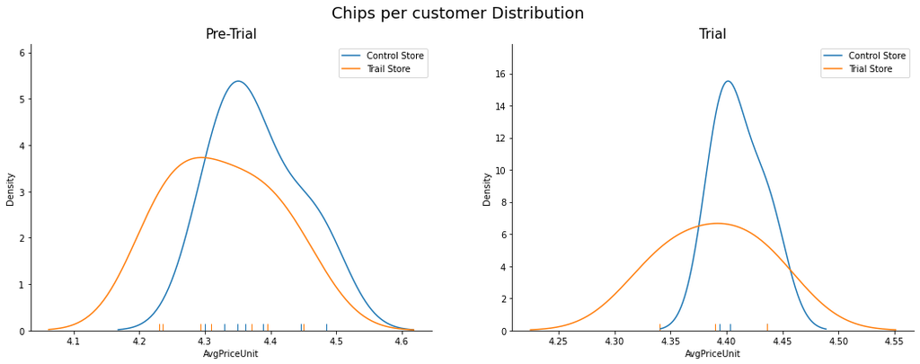

```python
# Lets visualise the distributions.
# Set up the chart
fig, axes = plt.subplots(1, 2, figsize=(18, 6), sharey=False)
fig.suptitle('Chips per customer Distribution', size=18)

# Pre Trial
sns.distplot(ax=axes[0], a=x.loc[(x.Store == 237) & (
    x.period_type == 'Pre-trial'), 'AvgPriceUnit'], hist=False, rug=True, label='Control Store')
sns.distplot(ax=axes[0], a=x.loc[(x.Store == 88) & (
    x.period_type == 'Pre-trial'), 'AvgPriceUnit'], hist=False, rug=True, label='Trail Store')
sns.despine()
axes[0].legend()
axes[0].set_title('Pre-Trial', size=15)

# Trail
sns.distplot(ax=axes[1], a=x.loc[(x.Store == 237) & (
    x.period_type == 'Trail'), 'AvgPriceUnit'], hist=False, rug=True, label='Control Store')
sns.distplot(ax=axes[1], a=x.loc[(x.Store == 88) & (
    x.period_type == 'Trail'), 'AvgPriceUnit'], hist=False, rug=True, label='Trial Store')
sns.despine()
axes[1].legend()
axes[1].set_title('Trial', size=15)
```

The average price per unit for both stores does not show any significant differance.

# Conclusion

We’ve found control stores 233, 155, 237 for trial stores 77, 86 and 88 respectively.